# Reg No - 18125760025

### Importing all Required libraries

```python
import pandas as pd
import matplotlib.pyplot as plt
import seaborn as sns
import cufflinks as cf
from plotly.offline import download_plotlyjs, init_notebook_mode, plot, iplot
from plotly import __version__
print(__version__)
```

```
3.4.2
```

### Importing Data Sets

```python
diamond = sns.load_dataset('diamonds')
mpg = sns.load_dataset('mpg')
```

```python
diamond.head()
```

|  | carat | cut | color | clarity | depth | table | price | x | y | z |
| --- | --- | --- | --- | --- | --- | --- | --- | --- | --- | --- |
| 0 | 0.23 | Ideal | E | SI2 | 61.5 | 55.0 | 326 | 3.95 | 3.98 | 2.43 |
| 1 | 0.21 | Premium | E | SI1 | 59.8 | 61.0 | 326 | 3.89 | 3.84 | 2.31 |
| 2 | 0.23 | Good | E | VS1 | 56.9 | 65.0 | 327 | 4.05 | 4.07 | 2.31 |
| 3 | 0.29 | Premium | I | VS2 | 62.4 | 58.0 | 334 | 4.20 | 4.23 | 2.63 |
| 4 | 0.31 | Good | J | SI2 | 63.3 | 58.0 | 335 | 4.34 | 4.35 | 2.75 |

```python
mpg.head()
```

|  | mpg | cylinders | displacement | horsepower | weight | acceleration | model_year | origin | name |
| --- | --- | --- | --- | --- | --- | --- | --- | --- | --- |
| 0 | 18.0 | 8 | 307.0 | 130.0 | 3504 | 12.0 | 70 | usa | chevrolet chevelle malibu |
| 1 | 15.0 | 8 | 350.0 | 165.0 | 3693 | 11.5 | 70 | usa | buick skylark 320 |
| 2 | 18.0 | 8 | 318.0 | 150.0 | 3436 | 11.0 | 70 | usa | plymouth satellite |
| 3 | 16.0 | 8 | 304.0 | 150.0 | 3433 | 12.0 | 70 | usa | amc rebel sst |
| 4 | 17.0 | 8 | 302.0 | 140.0 | 3449 | 10.5 | 70 | usa | ford torino |

### Question No. 1

```python
ctype = pd.DataFrame(diamond.groupby(['cut', 'color']).size()).reset_index().rename(columns= {0:'count'})
```

[output not shown]

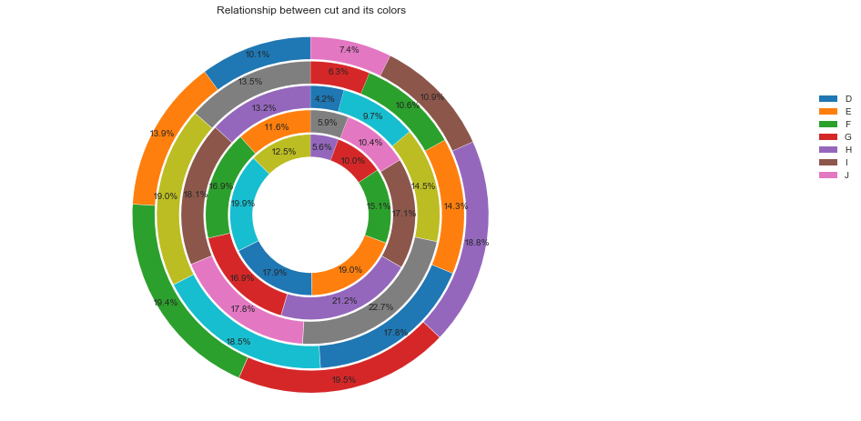

```python
plt.figure(figsize=(12,8))

pie = plt.pie(ctype[ctype['cut']=='Fair']['count'],labeldistance = 1.1,autopct = '%0.01f%%',pctdistance=0.95,startangle = 90,
            wedgeprops = dict(width = 0.5),radius = 4,explode=(0.01,0.01,0.01,0.01,0.01,0.01,0.01))

pie = plt.pie(ctype[ctype['cut']=='Good']['count'],labeldistance = 1.1,autopct = '%0.01f%%',pctdistance=0.95,startangle = 90,
            wedgeprops = dict(width = 0.5),radius = 3.45,explode=(0.01,0.01,0.01,0.01,0.01,0.01,0.01),)

pie = plt.pie(ctype[ctype['cut']=='Ideal']['count'],labeldistance = 1.1,autopct = '%0.01f%%',pctdistance=0.9,startangle = 90,
            wedgeprops = dict(width = 0.5),radius = 2.9,explode=(0.01,0.01,0.01,0.01,0.01,0.01,0.01),)

pie = plt.pie(ctype[ctype['cut']=='Premium']['count'],labeldistance = 1.1,autopct = '%0.01f%%',pctdistance=0.89,startangle = 90,
            wedgeprops = dict(width = 0.5),radius = 2.35,explode=(0.01,0.01,0.01,0.01,0.01,0.01,0.01),)

pie = plt.pie(ctype[ctype['cut']=='Very Good']['count'],labeldistance = 1.1,autopct = '%0.01f%%',pctdistance=0.85,startangle = 90,
            wedgeprops = dict(width = 0.5),radius = 1.8,explode=(0.01,0.01,0.01,0.01,0.01,0.01,0.01),)

plt.title('Relationship between cut and its colors', loc = 'center')
plt.axis('equal')
plt.legend(pie[0], labels = ctype[ctype['cut'] == 'Fair']['color'], loc = 'right',bbox_to_anchor = (1.4,0.7))
plt.show()
```

#### We can see from the above graph that in the given dataset,ideal cut is more in numbers compare to the other diffrent cuts and diffrent colors of the diamond as well.

### Question No. 2

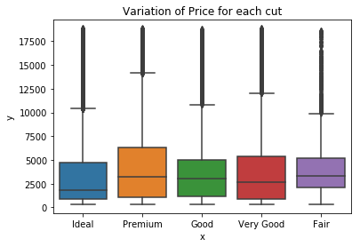

```python
sns.boxplot(x='cut',y='price',data=diamond)
plt.xlabel("x")
plt.ylabel("y")
plt.title("Variation of Price for each cut")
plt.show()
```

### Question No. 3

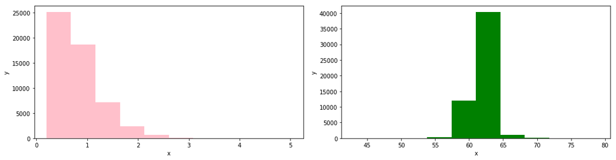

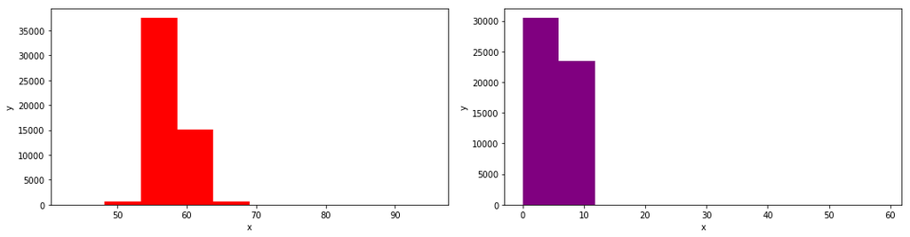

```python
diamond_head = diamond.head(1000)

fig = plt.figure(figsize= (15,4) )
plt.subplot(1,2,1)
plt.xlabel("x")
plt.ylabel("y")
plt.hist(diamond['carat'], color = 'pink')
plt.subplot(1,2,2)
plt.xlabel("x")
plt.ylabel("y")
plt.hist(diamond['depth'] , color = "green")
plt.tight_layout()

fig = plt.figure(figsize=(15,4))
plt.subplot(1,2,1)
plt.xlabel("x")
plt.ylabel("y")
plt.hist(diamond['table'] , color = "red")
plt.subplot(1,2,2)
plt.xlabel("x")
plt.ylabel("y")
plt.hist(diamond['y'] , color = "purple")

plt.tight_layout()
```

#### In the above graphs the x label represent the catagories

### Question No. 4

[output not shown]

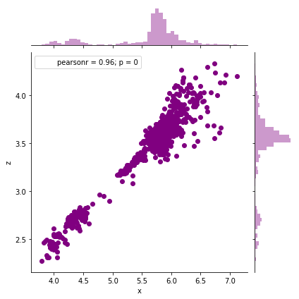

```python
sns.jointplot(x='x',y='z',data=diamond_head, color = 'purple',kind='scatter')
plt.show()
```

#### In the above graph the variation of x & z are in the straight line and the p = 0, pearsonr = 0.96%

### Question No. 5

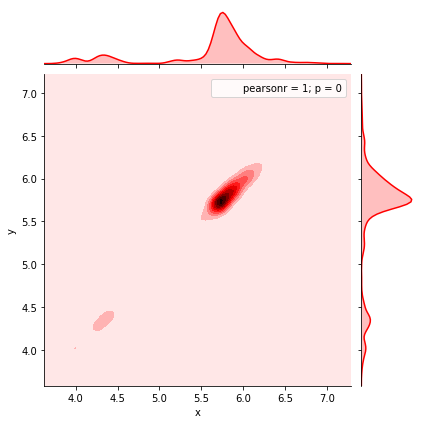

```python
sns.jointplot(x='x',y='y',data=diamond_head, color = 'red',kind='kde')
plt.show()
```

#### In the above graph the variation of x & y are more dark in above 5.5 of both x & y label and the p = 0, pearsonr = 1

### Question No. 6

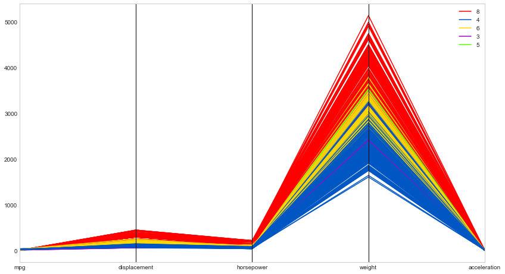

```python
from pandas.plotting import parallel_coordinates

mpg_numeric = mpg._get_numeric_data()
corr = mpg_numeric.corr()


fig = plt.figure(figsize = (14,8))


mpg_parallel = mpg_numeric.drop('model_year', axis = 1)


parallel_coordinates(mpg_parallel,'cylinders',colormap = plt.get_cmap('prism'))
plt.show()
```

#### In the above graph we are compare the cylinders to the each parameters.

#### Question No. 7

```
AxesSubplot(0.125,0.125;0.62x0.755)
```

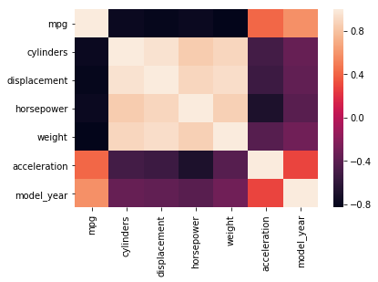

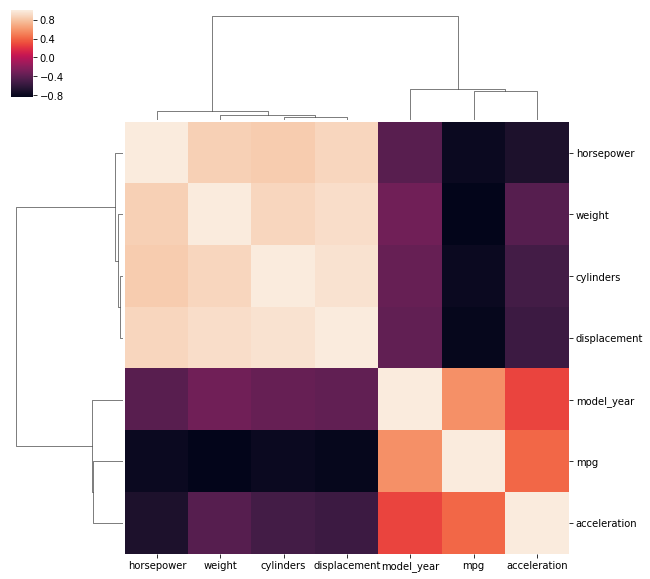

```python
print(sns.heatmap(mpg_numeric.corr()))
print(sns.clustermap(mpg_numeric.corr()))
```

#### In the above heat map & cluster map the varation of the different values based on different parameters

### Question No. 8

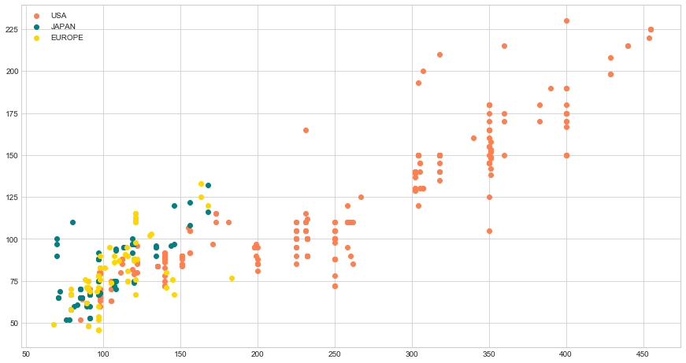

```python
fig = plt.figure(figsize=(15,8))

plt.style.use('seaborn-whitegrid')

#for USA
plt.scatter(mpg[mpg['origin']=='usa']['displacement'],
           mpg[mpg['origin']=='usa']['horsepower'],
            c = 'coral',label = 'USA') #c stands for color
#for JAPAN
plt.scatter(mpg[mpg['origin']=='japan']['displacement'],
           mpg[mpg['origin']=='japan']['horsepower'],
            c = 'teal',label = 'JAPAN') #c stands for color
#for EUROPE
plt.scatter(mpg[mpg['origin']=='europe']['displacement'],
           mpg[mpg['origin']=='europe']['horsepower'],
            c = 'gold',label = 'EUROPE') #c stands for color


plt.legend()
plt.grid(True)
plt.show()
```

#### In the above scatter plot we can easily see that variation of the dispersment based on the horse power in the USA, Compare to the other countries

### Question No.9

```
[8 4 6 3 5]
```

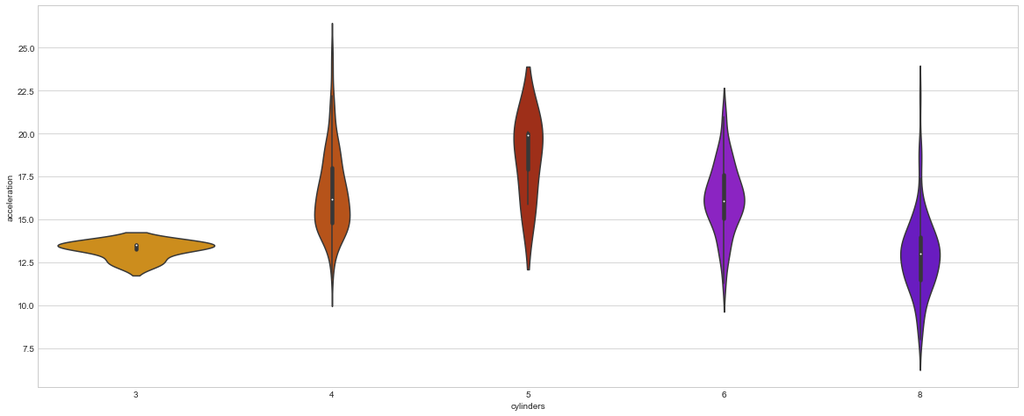

```python
print(mpg['cylinders'].unique())
mpg.head(2)
plt.figure(figsize=(20,8))

sns.violinplot(x= 'cylinders',y='acceleration',data = mpg,split = True, palette = 'gnuplot_r')
```

#### In the above violin plot we can see the outliers and it is same as boxplot but slight difference in the diagram is the violin plot spreads

### Question No. 10

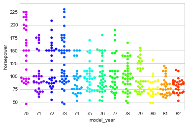

```python
sns.swarmplot(x='model_year',y='horsepower',data = mpg,palette = 'gist_rainbow_r')
plt.show()
```

#### In the above swarm plot we can easily see that the more data points